# Lista de Exercícios 1 - Resolução

Análise Multivariada

Autor

Prof. Dr. Washington S. da Silva

Data de Publicação

7 de novembro de 2023

## Questão 1

### 1.1

Utilizando a funcão `read_csv()` do pacote `readr`. Importe o arquivo de dados que está disponível na seguinte url e nomeie o objeto que vai receber os dados como `percepcao_marcas`.

**Solução**

```r
url <- "http://goo.gl/IQl8nc"
percepcao_marcas <- readr::read_csv(url)
```

### 1.2

Verifique a estrutra do objeto `percepcao_marcas` usando a funcão glimpse do pacote `dplyr` e verifique se os dados importados são consistentes com as informações.

**Solução**

```r
dplyr::glimpse(percepcao_marcas)
```

```
Rows: 1,000
Columns: 10
$ perform <dbl> 2, 1, 2, 1, 1, 2, 1, 2, 2, 3, 2, 1, 3, 1, 3, 3, 2, 3, 2, 2, 2,…
$ leader  <dbl> 4, 1, 3, 6, 1, 8, 1, 1, 1, 1, 1, 2, 3, 5, 1, 2, 1, 8, 5, 3, 2,…
$ latest  <dbl> 8, 4, 5, 10, 5, 9, 5, 7, 8, 9, 5, 7, 10, 7, 3, 7, 6, 9, 10, 9,…
$ fun     <dbl> 8, 7, 9, 8, 8, 5, 7, 5, 10, 8, 6, 7, 10, 10, 6, 6, 7, 9, 8, 10…
$ serious <dbl> 2, 1, 2, 3, 1, 3, 1, 2, 1, 1, 1, 2, 1, 2, 1, 1, 2, 4, 2, 2, 1,…
$ bargain <dbl> 9, 1, 9, 4, 9, 8, 5, 8, 7, 3, 1, 3, 3, 1, 3, 10, 1, 7, 6, 2, 5…
$ value   <dbl> 7, 1, 5, 5, 9, 7, 1, 7, 7, 3, 1, 2, 3, 3, 4, 5, 3, 10, 10, 6, …
$ trendy  <dbl> 4, 2, 1, 2, 1, 1, 1, 7, 5, 4, 1, 1, 3, 3, 4, 1, 5, 4, 5, 5, 3,…
$ rebuy   <dbl> 6, 2, 6, 1, 1, 2, 1, 1, 1, 1, 2, 5, 3, 1, 2, 3, 1, 2, 2, 2, 2,…
$ brand   <chr> "a", "a", "a", "a", "a", "a", "a", "a", "a", "a", "a", "a", "a…
```

Podemos verificar que há 1000 linhas e 10 colunas, assim, os dados são consistentes com as informações fornecidas.

### 1.3

Como você traduziria os 10 adjetivos usados para avaliar as marcas?

**Solução**

| adjetivo | tradução |
| --- | --- |
| *perform* | desempenho |
| *leader* | líder |
| *latest* | mais atualizada |
| *fun* | diversão |
| *serious* | séria |
| *bargain* | pechincha |
| *value* | valor |
| *trendy* | última moda |
| *rebuy* | comprar novamente |
| *brand* | marca. |

Entretanto, `brand`, obviamente, não é um adjetivo, é um substantivo, que podemos traduzir como marca.

## Questão 2

### 2.1

Podemos utilizar as funções mutate e across do pacote dplyr para converter as variáveis `perform`, `leader`, `latest`, `fun`, `serious`, `bargain`, `value`, `trendy` e `rebuy` para o tipo `integer` e a variável `brand` para o tipo `factor`. Verifique se a transformação foi bem sucedida usando função `glimpse()` do pacote dplyr no objeto `percepcao_df`.

**Solução**

```r
percepcao_df <- percepcao_marcas |>
  dplyr::mutate(across(1:9, as.integer),
                across(10, as.factor))

dplyr::glimpse(percepcao_df)
```

```
Rows: 1,000
Columns: 10
$ perform <int> 2, 1, 2, 1, 1, 2, 1, 2, 2, 3, 2, 1, 3, 1, 3, 3, 2, 3, 2, 2, 2,…
$ leader  <int> 4, 1, 3, 6, 1, 8, 1, 1, 1, 1, 1, 2, 3, 5, 1, 2, 1, 8, 5, 3, 2,…
$ latest  <int> 8, 4, 5, 10, 5, 9, 5, 7, 8, 9, 5, 7, 10, 7, 3, 7, 6, 9, 10, 9,…
$ fun     <int> 8, 7, 9, 8, 8, 5, 7, 5, 10, 8, 6, 7, 10, 10, 6, 6, 7, 9, 8, 10…
$ serious <int> 2, 1, 2, 3, 1, 3, 1, 2, 1, 1, 1, 2, 1, 2, 1, 1, 2, 4, 2, 2, 1,…
$ bargain <int> 9, 1, 9, 4, 9, 8, 5, 8, 7, 3, 1, 3, 3, 1, 3, 10, 1, 7, 6, 2, 5…
$ value   <int> 7, 1, 5, 5, 9, 7, 1, 7, 7, 3, 1, 2, 3, 3, 4, 5, 3, 10, 10, 6, …
$ trendy  <int> 4, 2, 1, 2, 1, 1, 1, 7, 5, 4, 1, 1, 3, 3, 4, 1, 5, 4, 5, 5, 3,…
$ rebuy   <int> 6, 2, 6, 1, 1, 2, 1, 1, 1, 1, 2, 5, 3, 1, 2, 3, 1, 2, 2, 2, 2,…
$ brand   <fct> a, a, a, a, a, a, a, a, a, a, a, a, a, a, a, a, a, a, a, a, a,…
```

Vemos que a transformação foi bem sucedida, as variáveis `perform`, `leader`, `latest`, `fun`, `serious`, `bargain`, `value`, `trendy` e `rebuy` foram convertidas para o tipo integer e a variável `brand` foi convertida para o tipo, mais precisamente, para a classe `factor`.

## Questão 3

### 3.1

Podemos usar a funcão `corrplot` do pacote corrplot para explorar a correlação bivariada entre as variáveis. O que você conclui observando este gráfico de correlações: Há correlações relevantes entre as variáveis (avaliações dadas pelos consumidores às marcas)? Você consegue visualizar os clusters formados? Quantos e quais são?

**Solução**

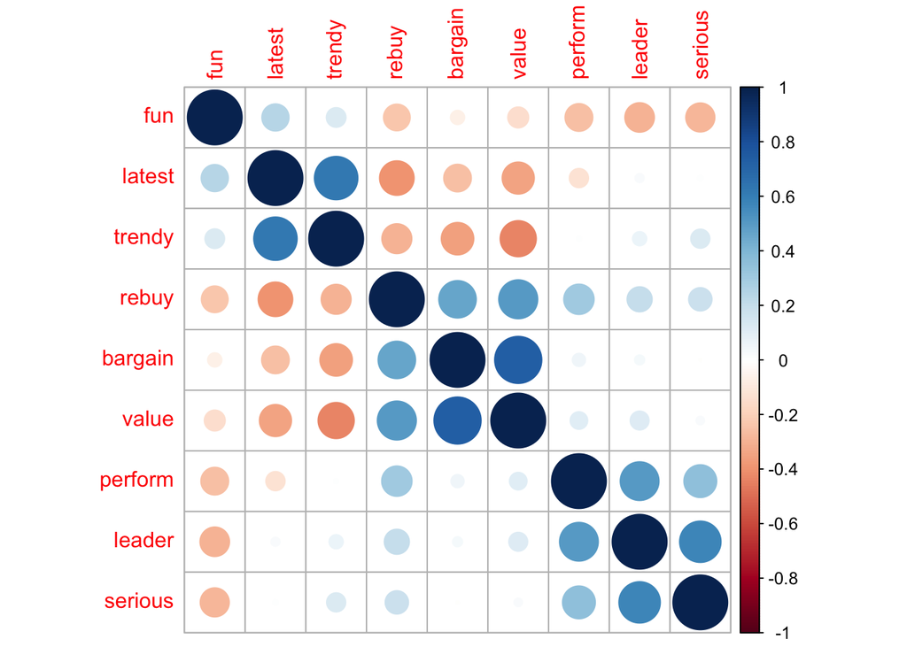

```r
corrplot::corrplot(cor(percepcao_df[ , 1:9]) , order = "hclust")
```

Neste gráfico, o tamanho do coeficiente de correlação entre as variáveis é proporcional à àrea dos círculos. Além disso, a cor do círculo varia entre azul escuro, que indica forte correlação positiva, $r$ é próximo de +1, e vermelho escuro, que indica forte correlação negativa, $r$ é próximo de -1. A cor branca indica ausência de correlação, $r$ é próximo de 0.

Assim, podemos ver que a forte correlação positiva entre `trendy` e `latest` e entre `value` e `bargain`. Além disso, podemos ver que a uma correlação negativa moderada entre `rebuy` e `latest` e `value` e `trendy`. Portanto, podemos afirmar que há algumas correlacões relevantes entre as variáveis.

Podemos visualizar a formação de três clusters envolvendo variáveis similares, o primeiro envolve `fun`, `latest` e `trendy`, o segundo `rebuy`, `bargain` e `value`, e o terceiro `perform`, `leader` e `serious`.

## Questão 4

### 4.1

Utilizando os dados `percepcao_df`, daça uma análise de componentes principais usando a função `PCA()` do pacote `FactoMineR` e armazene os resultados no objeto `marcas_pca`. Utilize os argumentos `scale.unit = TRUE`, `graph = F`, qual o valor você deve estabelecer para o argumento `ncp`?

**Solução**

```r
marcas_pca <- FactoMineR::PCA(percepcao_df[, 1:9],
                             scale.unit = TRUE,
                             ncp = 10,
                             graph = F)
summary(marcas_pca)
```

```
Call:
FactoMineR::PCA(X = percepcao_df[, 1:9], scale.unit = TRUE, ncp = 10,
     graph = F)


Eigenvalues
                       Dim.1   Dim.2   Dim.3   Dim.4   Dim.5   Dim.6   Dim.7
Variance               2.979   2.097   1.079   0.727   0.638   0.535   0.390
% of var.             33.103  23.295  11.992   8.080   7.084   5.943   4.334
Cumulative % of var.  33.103  56.398  68.390  76.470  83.554  89.497  93.831
                       Dim.8   Dim.9
Variance               0.312   0.243
% of var.              3.467   2.702
Cumulative % of var.  97.298 100.000

Individuals (the 10 first)
            Dist    Dim.1    ctr   cos2    Dim.2    ctr   cos2    Dim.3    ctr
1       |  2.750 |  1.010  0.034  0.135 | -1.623  0.126  0.348 |  1.815  0.305
2       |  3.199 | -1.537  0.079  0.231 | -1.837  0.161  0.330 | -2.003  0.372
3       |  3.050 |  1.212  0.049  0.158 | -2.302  0.253  0.570 |  0.698  0.045
4       |  2.535 | -0.818  0.022  0.104 | -0.731  0.026  0.083 |  0.519  0.025
5       |  3.931 |  0.897  0.027  0.052 | -3.274  0.511  0.694 |  0.841  0.066
6       |  3.121 |  1.082  0.039  0.120 | -0.587  0.016  0.035 |  0.906  0.076
7       |  3.184 | -1.103  0.041  0.120 | -2.221  0.235  0.487 | -1.279  0.152
8       |  2.831 | -0.229  0.002  0.007 | -1.616  0.125  0.326 |  1.053  0.103
9       |  3.098 | -0.758  0.019  0.060 | -2.342  0.262  0.571 |  1.519  0.214
10      |  2.564 | -1.838  0.113  0.514 | -1.434  0.098  0.313 | -0.111  0.001
          cos2
1        0.436 |
2        0.392 |
3        0.052 |
4        0.042 |
5        0.046 |
6        0.084 |
7        0.161 |
8        0.138 |
9        0.240 |
10       0.002 |

Variables
           Dim.1    ctr   cos2    Dim.2    ctr   cos2    Dim.3    ctr   cos2
perform |  0.410  5.639  0.168 |  0.608 17.633  0.370 | -0.040  0.149  0.002 |
leader  |  0.355  4.236  0.126 |  0.758 27.439  0.575 |  0.099  0.905  0.010 |
latest  | -0.639 13.718  0.409 |  0.292  4.058  0.085 |  0.553 28.380  0.306 |
fun     | -0.433  6.303  0.188 | -0.363  6.269  0.131 |  0.434 17.457  0.188 |
serious |  0.276  2.552  0.076 |  0.739 26.058  0.546 |  0.042  0.165  0.002 |
bargain |  0.689 15.934  0.475 | -0.316  4.774  0.100 |  0.509 24.000  0.259 |
value   |  0.772 20.022  0.597 | -0.275  3.603  0.076 |  0.384 13.634  0.147 |
trendy  | -0.606 12.322  0.367 |  0.461 10.144  0.213 |  0.385 13.757  0.148 |
rebuy   |  0.758 19.274  0.574 |  0.022  0.023  0.000 |  0.129  1.553  0.017 |
```

### 4.2

Utilizando o objeto `marcas_pca` e a função `fviz_screeplot()` do pacote `factoextra`, faça um Scree Plot. Considerando esse gráfico, quantos componentes você considera suficientes para explicar a variação total dos cados?

**Solução**

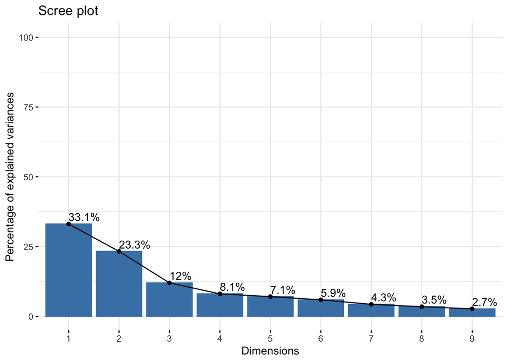

```r
factoextra::fviz_screeplot(
  marcas_pca,
  choice = "variance",
  addlabels = TRUE,
  ylim = c(0, 100)
)
```

Conforme comentamos em aula, não há resposta simples e única para esta questão, ela depende da precisão que se deseja para a a redução da dimensão dos dados, assim 6 ou 7 componentes constituem um número de componentes bastante adequado.

### 4.3

Utilize a função `fviz_pca_var()` do pacote `factoextra` para criar um biplot das variáveis, isto é, dos atributos/adjetivos atribuídos pelos entrevistados as marcas. Há algum padrão relevante? Explique.

**Solução**

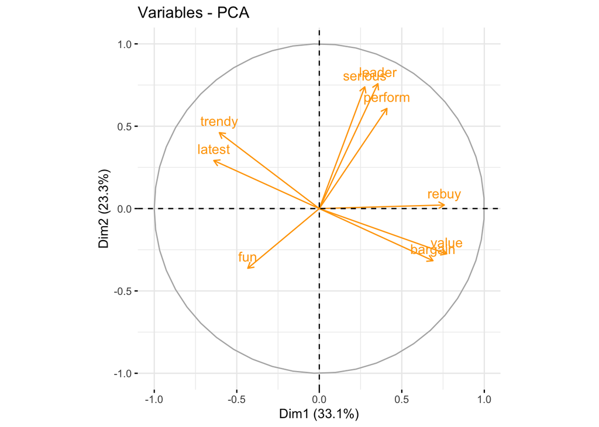

```r
factoextra::fviz_pca_var(marcas_pca, col.var = "orange")
```

Podemoos visualizar que os 9 adjetivos são mapeados em 4 categorias:

- **liderança**: `serious`, `leader` e `perform` no quadrante direito superior.
- **valor**: `rebuy`, `value` e `bargain` no quadrante direito inferior,
- **tendência**: `trendy` e `latest` no quadrante esquerdo superior.
- **diversão**: `fun` isolada no quadrante esquerdo inferior.

### 4.4

Utilize a função `fviz_pca_ind()` do pacote `factoextra` para criar um biplot dos indivíduos, isto é, das marcas avaliadas. Há algum padrão relevante? Explique.

**Solução**

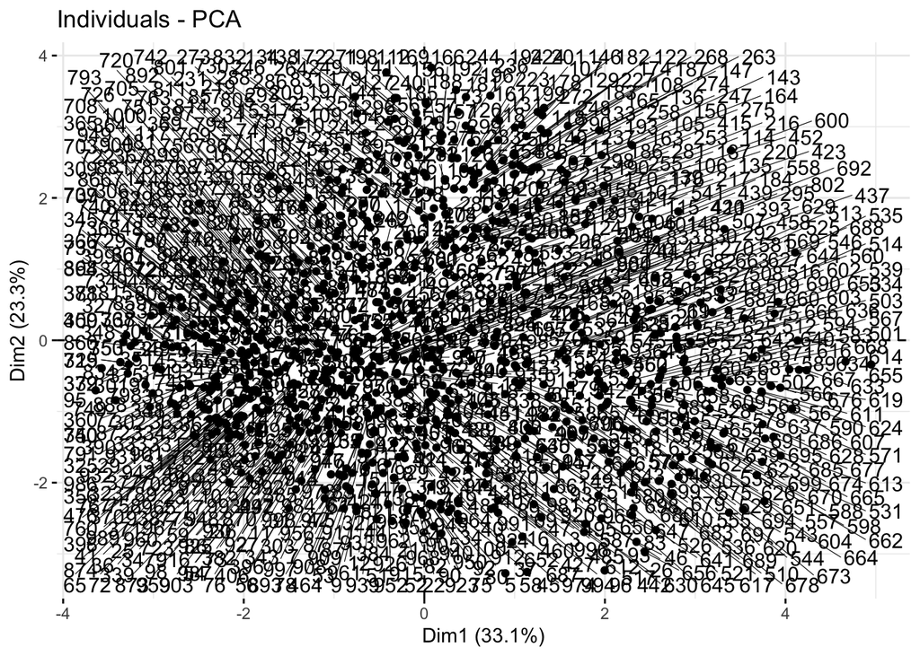

```r
factoextra::fviz_pca_ind(marcas_pca,
                         select.ind = list("contrib"),
                         repel = TRUE)
```

É impossível interpretar o gráfico contendo tantas avaliações individuais, não é possível vizualizar nenhum padrão relevante entre as 1.000 avaliações individuais. Trata-se de uma limitacão desses mapas perceptuais, nào é possível interpretá-los quando há centenas de “indivíduos”.

### 4.5

Utilizando a função `fviz_pca_biplot` do pacote `factoextra` crie um biplot contendo as variáveis e os indivíduos. Analise o resultado desta pesquisa simulada de *percepção de marcas*.

**Solução**

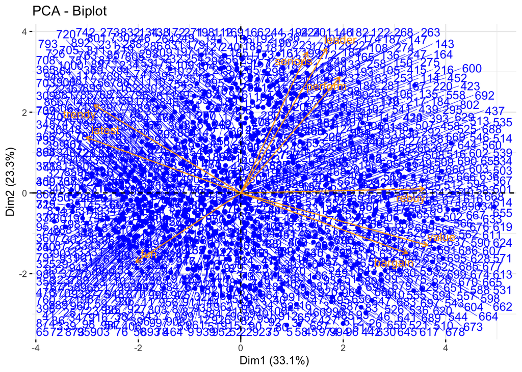

```r
factoextra::fviz_pca_biplot(marcas_pca,
                label = "all",
                col.var = "orange",
                col.ind = "blue",
                repel = TRUE)
```

Como vimos na questão 4.3, ainda é possível ver neste biplot que os 9 adjetivos podem ser agrupados em 4 categorias: liderança, valor, tendência e diversão.

Entretanto, novamente nos deparamos com o problema já constatado na questão 4.4: a nuvem das avaliações individuais dos entrevistados é muito densa e não nos informa sobre as posições das marcas. Portanto, novamente constatamos que é impossível interpretar um biplot contendo tantos indivíduos ou avaliações individuais neste caso.

## EXTRA: Estratégia para lidar com muitos “indivíduos”

**Avaliações médias agregadas por marca**

Uma possível solução para tornar interpretável o biplot envolvendo as variáveis, adjetivos associados às marcas no caso, e os indivíduos, avaliações individuais das marcas pelos consumidores, é realizar a análise de componentes principais usando as avaliações **médias** dos consumidores **agregadas por marca**.

Inicialmente, devemos nos lembrar que a pesquisa consistiu em cada um dos 100 consumidores avaliar cada uma das 10 marcas em relação a cada um dos os adjetivos apresentados utilizando a escala entre 1 e 10.

Podemos visualizar essa estrutura utilizando a função count do pacote dplyr:

```r
percepcao_marcas |> dplyr::count(brand)
```

```
# A tibble: 10 × 2
   brand     n
   <chr> <int>
 1 a       100
 2 b       100
 3 c       100
 4 d       100
 5 e       100
 6 f       100
 7 g       100
 8 h       100
 9 i       100
10 j       100
```

Assim, o que estamos denominando avaliacão ou classificação média atribuída pelos consumidores, agregadas por marcas, consistem em, por exemplo, calcular a nota média da marca “a” em relação ao adjetivo `perform` somando as 100 notas atribuídas pelos 100 consumidores entrevistados e dividindo por 100, assim por diante para cada uma das 10 marcas e 9 adjetivos.

Antes de calcular as avaliações médias agregadas por marca, vamos tornar o objetov `percepcao_marcas` mais adequado para a análise de componentes principais.

Inicialmente, vamos padronizar as 9 variáveis, ou seja, subtrair a média e dividir pelo desvio-padrão. Podemos fazer essa operação utilizando a função `scale`:

```r
percepcao_marcas[, 1:9] <- scale(percepcao_marcas[, 1:9])
head(percepcao_marcas)
```

```
# A tibble: 6 × 10
  perform leader latest    fun serious bargain  value trendy  rebuy brand
    <dbl>  <dbl>  <dbl>  <dbl>   <dbl>   <dbl>  <dbl>  <dbl>  <dbl> <chr>
1  -0.777 -0.160  0.586  0.704  -0.836  1.78    1.11  -0.445  0.893 a
2  -1.09  -1.31  -0.713  0.340  -1.20  -1.22   -1.39  -1.17  -0.679 a
3  -0.777 -0.543 -0.388  1.07   -0.836  1.78    0.276 -1.54   0.893 a
4  -1.09   0.607  1.24   0.704  -0.476 -0.0971  0.276 -1.17  -1.07  a
5  -1.09  -1.31  -0.388  0.704  -1.20   1.78    1.94  -1.54  -1.07  a
6  -0.777  1.37   0.911 -0.389  -0.476  1.40    1.11  -1.54  -0.679 a
```

Podemos usar a função `aggregate()` para encontrar as avaliações médias agregadas por marca, ou seja, a média de cada variável (adjetivo) por marca.

```r
percepcao_marcas_media <- aggregate(. ~ brand, data = percepcao_marcas, mean)
percepcao_marcas_media
```

```
   brand     perform     leader     latest        fun     serious     bargain
1      a -0.88591874 -0.5279035  0.4109732  0.6566458 -0.91894067  0.21409609
2      b  0.93087022  1.0707584  0.7261069 -0.9722147  1.18314061  0.04161938
3      c  0.64992347  1.1627677 -0.1023372 -0.8446753  1.22273461 -0.60704302
4      d -0.67989112 -0.5930767  0.3524948  0.1865719 -0.69217505 -0.88075605
5      e -0.56439079  0.1928362  0.4564564  0.2958914  0.04211361  0.55155051
6      f -0.05868665  0.2695106 -1.2621589 -0.2179102  0.58923066  0.87400696
7      g  0.91838369 -0.1675336 -1.2849005 -0.5167168 -0.53379906  0.89650392
8      h -0.01498383 -0.2978802  0.5019396  0.7149495 -0.14145855 -0.73827529
9      i  0.33463879 -0.3208825  0.3557436  0.4124989 -0.14865746 -0.25459062
10     j -0.62994504 -0.7885965 -0.1543180  0.2849595 -0.60218870 -0.09711188
         value      trendy       rebuy
1   0.18469264 -0.52514473 -0.59616642
2   0.15133957  0.74030819  0.23697320
3  -0.44067747  0.02552787 -0.13243776
4  -0.93263529  0.73666135 -0.49398892
5   0.41816415  0.13857986  0.03654811
6   1.02268859 -0.81324496  1.35699580
7   1.25616009 -1.27639344  1.36092571
8  -0.78254646  0.86430070 -0.60402622
9  -0.80339213  0.59078782 -0.20317603
10 -0.07379367 -0.48138267 -0.96164748
```

Esse cálculo responde a questão de negócios mais simples para os dados da pesquisa: “Qual é a posição média de uma marca em cada adjetivo?”

Para simplificar o objeto `percepcao_marcas_media`, vamos usar os nomes das marcas como nome das linhas, os quais a funcão `agregate()` colocou na primeira coluna chamada `brand` e, em seguida, vamos remover a coluna `brand` pois ela se tornou redundante.

A matriz resultante ficará bem formatada com marcas como nomes das linhas e os adjetivos (variáveis) nas colunas:

```r
# define os nomes das marcas como nomes das linhas
rownames(percepcao_marcas_media) <- percepcao_marcas_media[, 1]

# remove a coluna brand do objeto percepcao_marcas_media
percepcao_marcas_media <- percepcao_marcas_media[, -1]
percepcao_marcas_media
```

```
      perform     leader     latest        fun     serious     bargain
a -0.88591874 -0.5279035  0.4109732  0.6566458 -0.91894067  0.21409609
b  0.93087022  1.0707584  0.7261069 -0.9722147  1.18314061  0.04161938
c  0.64992347  1.1627677 -0.1023372 -0.8446753  1.22273461 -0.60704302
d -0.67989112 -0.5930767  0.3524948  0.1865719 -0.69217505 -0.88075605
e -0.56439079  0.1928362  0.4564564  0.2958914  0.04211361  0.55155051
f -0.05868665  0.2695106 -1.2621589 -0.2179102  0.58923066  0.87400696
g  0.91838369 -0.1675336 -1.2849005 -0.5167168 -0.53379906  0.89650392
h -0.01498383 -0.2978802  0.5019396  0.7149495 -0.14145855 -0.73827529
i  0.33463879 -0.3208825  0.3557436  0.4124989 -0.14865746 -0.25459062
j -0.62994504 -0.7885965 -0.1543180  0.2849595 -0.60218870 -0.09711188
        value      trendy       rebuy
a  0.18469264 -0.52514473 -0.59616642
b  0.15133957  0.74030819  0.23697320
c -0.44067747  0.02552787 -0.13243776
d -0.93263529  0.73666135 -0.49398892
e  0.41816415  0.13857986  0.03654811
f  1.02268859 -0.81324496  1.35699580
g  1.25616009 -1.27639344  1.36092571
h -0.78254646  0.86430070 -0.60402622
i -0.80339213  0.59078782 -0.20317603
j -0.07379367 -0.48138267 -0.96164748
```

Agora podemos realizar a análise de componentes principais usando as avaliações **médias** dos consumidores **agregadas por marca** contidas no objeto `percepcao_marcas_media`:

```r
percepcap_media_pca <- FactoMineR::PCA(
  percepcao_marcas_media,
  scale.unit = TRUE,
  ncp = 10,
  graph = F
)
summary(percepcap_media_pca)
```

```
Call:
FactoMineR::PCA(X = percepcao_marcas_media, scale.unit = TRUE,
     ncp = 10, graph = F)


Eigenvalues
                       Dim.1   Dim.2   Dim.3   Dim.4   Dim.5   Dim.6   Dim.7
Variance               4.556   3.010   0.591   0.378   0.260   0.134   0.046
% of var.             50.624  33.445   6.570   4.202   2.888   1.493   0.514
Cumulative % of var.  50.624  84.069  90.640  94.842  97.730  99.223  99.737
                       Dim.8   Dim.9
Variance               0.021   0.002
% of var.              0.236   0.026
Cumulative % of var.  99.974 100.000

Individuals
            Dist    Dim.1    ctr   cos2    Dim.2    ctr   cos2    Dim.3    ctr
a       |  2.681 | -1.338  3.932  0.249 | -2.075 14.307  0.599 |  0.812 11.156
b       |  3.574 |  1.279  3.589  0.128 |  3.166 33.293  0.785 |  0.673  7.656
c       |  3.280 |  0.948  1.971  0.083 |  2.871 27.384  0.766 | -0.437  3.234
d       |  2.922 | -2.673 15.682  0.837 | -0.076  0.019  0.001 | -0.670  7.589
e       |  1.663 | -0.051  0.006  0.001 | -0.454  0.686  0.075 |  1.563 41.293
f       |  3.610 |  3.256 23.264  0.813 | -1.040  3.594  0.083 |  0.279  1.319
g       |  4.322 |  3.724 30.432  0.742 | -1.748 10.150  0.164 | -1.067 19.249
h       |  2.672 | -2.443 13.095  0.835 |  0.547  0.993  0.042 | -0.377  2.398
i       |  1.881 | -1.422  4.438  0.571 |  0.447  0.665  0.057 | -0.561  5.320
j       |  2.361 | -1.279  3.591  0.293 | -1.638  8.910  0.481 | -0.215  0.785
          cos2
a        0.092 |
b        0.035 |
c        0.018 |
d        0.053 |
e        0.883 |
f        0.006 |
g        0.061 |
h        0.020 |
i        0.089 |
j        0.008 |

Variables
           Dim.1    ctr   cos2    Dim.2    ctr   cos2    Dim.3    ctr   cos2
perform |  0.609  8.137  0.371 |  0.585 11.377  0.342 | -0.370 23.157  0.137 |
leader  |  0.528  6.119  0.279 |  0.792 20.843  0.627 |  0.244 10.056  0.059 |
latest  | -0.761 12.695  0.578 |  0.435  6.279  0.189 |  0.381 24.591  0.145 |
fun     | -0.716 11.257  0.513 | -0.580 11.193  0.337 |  0.117  2.301  0.014 |
serious |  0.453  4.500  0.205 |  0.823 22.527  0.678 |  0.187  5.940  0.035 |
bargain |  0.771 13.057  0.595 | -0.482  7.715  0.232 |  0.353 21.105  0.125 |
value   |  0.856 16.086  0.733 | -0.417  5.790  0.174 |  0.258 11.274  0.067 |
trendy  | -0.665  9.700  0.442 |  0.651 14.079  0.424 |  0.067  0.761  0.005 |
rebuy   |  0.917 18.450  0.841 | -0.077  0.197  0.006 | -0.069  0.816  0.005 |
```

Veja que utilizamos `scale=TRUE` para padronizar os dados, mesmo que os dados brutos já tenham sido padronizados, esse procedimento é recomendado porque as médias agregadas têm uma escala diferente da escala dos dados brutos padronizados.

Veja que os resultados mostram que os dois primeiros componentes respondem por 84% da variâção total das classificações médias, o que é muito bom para a qualidade de um biplot, como sabemos.

Finalmente, podemos vamos criar um biplot usando as avaliacões médias agregadas por marca:

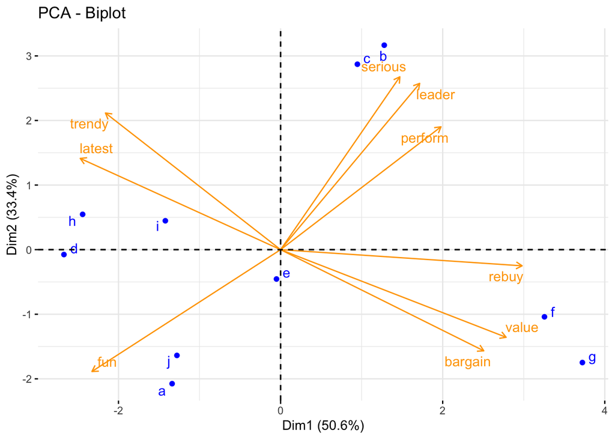

```r
factoextra::fviz_pca_biplot(percepcap_media_pca,
                label = "all",
                col.var = "orange",
                col.ind = "blue",
                repel = TRUE)
```

O biplot para as classificações médias fornece um mapa perceptivo interpretável, mostrando onde as marcas estão posicionadas em relação aos dois primeiros componentes principais.

Antes de interpretar o novo mapa, repare que o uso das médias não alterou a estrutura geral do biplot em relação ao resultado das questões 4.3 e 4.5.

Este novo mapa tem omesmo agrupamento geral de adjetivos e estrutura relacional, por exemplo, `serious`, `leader` e `perform` continuam muito relacionados, enquanto `fun` está bastante distante dos outros adjetivos. Assim, as posições das variáveis nos componentes são consistentes com a PCA do conjunto completo de observações.

Com esse mapa, pode-se formular perguntas e depois consultar os dados subjacentes para respondê-las.

### Suponha que você seja o gerente de marca da marca “e”, o que o mapa lhe diz?

Por um lado, a sua marca está no centro, portanto, parece não ser bem diferenciada em nenhuma das dimensões.

Isso pode ser bom ou ruim, dependendo dos seus objetivos estratégicos. Se o seu objetivo é ser uma marca segura que atraia muitos consumidores, então uma posição relativamente indiferenciada como esta poderia ser desejável.

Por outro lado, se você deseja que sua marca tenha uma percepção forte e diferenciada, essa constatação seria indesejada.

### O que você deve fazer em relação ao posicionamento da sua marca “e”?**

Novamente, depende dos objetivos estratégicos. Se você deseja aumentar a diferenciação, uma possibilidade seria tomar medidas para mudar sua marca em alguma direção no mapa.

Suponha que você queira seguir na direção da marca “c”. Você pode observar as diferenças específicas de “e” em relação a “c” nos dados:

```r
# compara as avaliacoes medias das marcas c e e
percepcao_marcas_media["c", ] - percepcao_marcas_media["e", ]
```

```
   perform    leader     latest       fun  serious   bargain      value
c 1.214314 0.9699315 -0.5587936 -1.140567 1.180621 -1.158594 -0.8588416
     trendy      rebuy
c -0.113052 -0.1689859
```

As diferenças mostram que “e” é relativamente mais forte do que “c” em `value` e `fun`, o que sugere diminuir as mensagens ou outros atributos que os reforcem (assumindo, é claro, que você realmente deseja avançar na direção da marca “c”).

Da mesma forma, a marca “c” é mais forte em `perform` e `serious`, então esses poderiam ser aspectos do produto ou mensagem a serem fortalecidos.

### Como descobrimos como nos posicionar nesta região?

Vamos supor que a diferença reflita aproximadamente a média dessas quatro marcas. Podemos encontrar essa média usando a função `colMeans()` nas linhas das marcas, e então calculando a diferença entre a marca “e” e essa média:

```r
# em direcao ao espaco nao ocupado entre b/c & g/f
colMeans(percepcao_marcas_media[c("b", "c", "f", "g"),]) -
         percepcao_marcas_media["e",]
```

```
   perform    leader     latest        fun   serious    bargain      value
e 1.174513 0.3910396 -0.9372789 -0.9337707 0.5732131 -0.2502787 0.07921355
      trendy     rebuy
e -0.4695304 0.6690661
```

Isto sugere que a marca “e” poderia focar a lacuna aumentando a sua ênfase em `perform` e ao mesmo tempo que reduzir a ênfase em `latest` e `fun`.